# Inference for a single mean with known variance

### Load packages

```r
library(statsr)
library(dplyr)
library(ggplot2)
```

### The data

Load the data

```r
set.seed(15)
margins <- rnorm(24,150,800)
df <- data.frame("Margins" = margins)
```

```r
str(df)
```

```
## 'data.frame':    24 obs. of  1 variable:
##  $ Margins: num  357 1615 -122 868 540 ...
```

```r
mean(df$Margins)
```

```
## [1] 247.4781
```

```r
sd(df$Margins)
```

```
## [1] 719.382
```

## T-Test one-tail with sig. level = 0.05

Let

$$H_0: \mu = 0$$
$$H_0: \mu > 0$$

```r
SE = sd(df$Margins)/sqrt(24)
t = (mean(df$Margins))/SE
pv = pt(q=t,df=23,lower.tail = FALSE)
pv
```

```
## [1] 0.05272423
```

There is not sufficient data in order for us to reject H_0. In order to relax the condition, we would have to adjust the sig. level $\alpha$. It is not clear or easy to justify what increasing $\alpha$ actually means beyond “we want to be less confident”.

## EDA and Bayesian Inference - `margins`

As with the frequentist approach we use these data to perform basic inference on $\mu$ the average. To do this we will use the `bayes_inference` function which will allow us to construct credible intervals and calculate Bayes factors for a variety of different circumstances.

In order to construct a credible interval we must first provide the data, and then indicate that we want a credible interval (`type="ci"`) for a mean (`statistic="mean"`).

```r
bayes_inference(y = margins, data = df, statistic = "mean", type = "ci")
```

```
## Single numerical variable
## n = 24, y-bar = 247.4781, s = 719.382
## (Assuming improper prior: P(mu, sigma^2) = 1/sigma^2)
##
## 95% CI: (-55.8793 , 551.632)
##
## Post. mean   = 247.5697
## Post. median = 247.7079
## Post. mode   = 245.9381
```

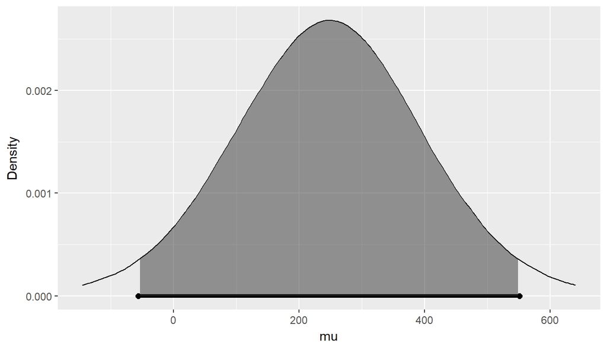

The above result gives us a 95% Credible Interval. i.e. there is a 95% probability that the mean lies within this range.

The credible level for the interval can be specified using the `cred_level` argument.

```r
bayes_inference(y = margins, data = df, statistic = "mean", type = "ci", cred_level = 0.99)
```

```
## Single numerical variable
## n = 24, y-bar = 247.4781, s = 719.382
## (Assuming improper prior: P(mu, sigma^2) = 1/sigma^2)
##
## 99% CI: (-163.3798 , 658.8852)
##
## Post. mean   = 247.7953
## Post. median = 247.7014
## Post. mode   = 245.7058
```

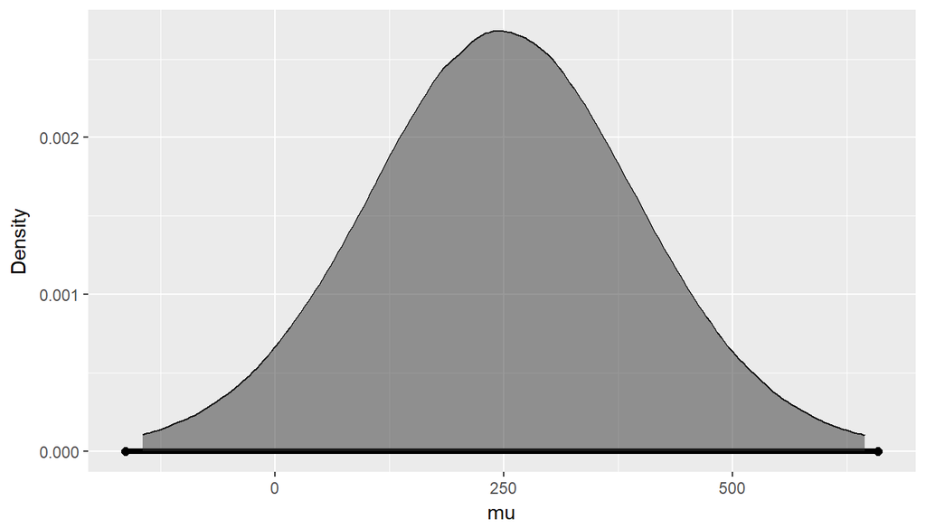

We can also conduct a Bayesian hypothesis test by calculating a Bayes factor, let’s test to see if the average is significantly different from 0.

$$H_1: \mu = 0$$
$$H_2: \mu \ne 0$$

To conduct this hypothesis test we will again use the `bayes_inference` function but this time specify `type="ht"`, we will then also need to provide the `null` and `alternative` arguments which define the null value (0) and the type of alternative hypothesis (`"twosided"`).

```r
BI = bayes_inference(y = margins, data = df, statistic = "mean", type = "ht", null = 0, alternative = "twosided")
```

```
## Single numerical variable
## n = 24, y-bar = 247.4781, s = 719.382
## (Assuming improper prior: P(mu, sigma^2) = 1/sigma^2)
##
## Hypotheses:
## H1: mu = 0
## H2: mu != 0
##
## Priors:
## P(H1) = 0.5
## P(H2) = 0.5
##
## Results:
## BF[H1:H2] = 1.3868
## P(H1|data) = 0.581
## P(H2|data) = 0.419
```

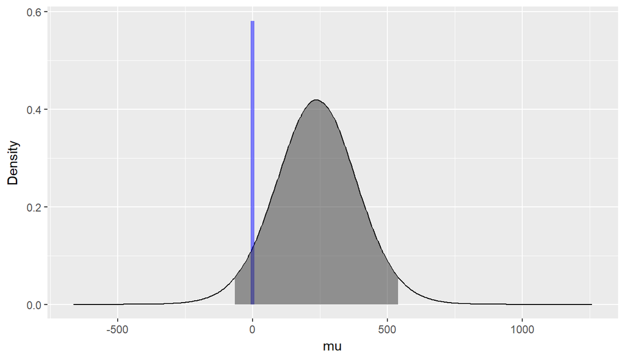

```r
print(BI)
```

```
## $hypothesis_prior
##  H1  H2
## 0.5 0.5
##
## $order
## [1] "H1:H2"
##
## $O
## H1
##  1
##
## $BF
## [1] 1.38684
##
## $PO
##      H1
## 1.38684
##
## $post_H1
##       H1
## 0.581036
##
## $post_H2
##       H1
## 0.418964
```

The graphical results show the magnitude of $P(H_1 ~|~ data)$ with the blue line and the posterior of $\mu$ given $H_2$ (scaled by $P(H_2 ~|~ data)$) via the black curve. The 95% credible interval for $\mu|data,H_2$ is given in grey.

```r
BI$post_H1
```

```
##       H1
## 0.581036
```

```r
BI$post_H2
```

```
##       H1
## 0.418964
```

Here, we have $P(H_1 ~|~ data) = 0.581$ and $P(H_2 ~|~ data) = 0.419$. So

$$P(\mu > 0) = P(\mu > 0 ~|~ H_1)*P(H_1) + P(\mu > 0 ~|~ H_2)*P(H_2) = P(\mu > 0 ~|~ H_2)*P(H_2)$$

```r
pnorm(q=-0.637,lower.tail = FALSE)
```

```
## [1] 0.7379376
```

$$P(\mu > 0) = P(\mu > 0 ~|~ H_2)*P(H_2) = 0.7379376*0.419 = 0.3091959$$

Here, instead of simply rejecting the idea that the changes affected the mean margin, a probability is assigned to the notion.

Also, instead of simply changing the significance level in order to be able to reject the null hypothesis, here, we can update prior distribution ($\mu ~ N(10,\sigma^2)$) in order to include our prior information into the model.

## New Data

```r
set.seed(1)
margins <- rnorm(24,350,1000)
margins <- c(0,-0.03,-0.01,0.05,-0.03,0.08,-0.01,-0.01,0.03,0.02,-0.03,0.09,-0.01,0.04,-0.02,0,0.1,0.08,0.08,0.05,0,0.06,0.04,0.02)
df <- data.frame("Margins" = margins)

#df$margins = margins
#data(DataFrame)
```

```r
str(df)
```

```
## 'data.frame':    24 obs. of  1 variable:
##  $ Margins: num  0 -0.03 -0.01 0.05 -0.03 0.08 -0.01 -0.01 0.03 0.02 ...
```

```r
mean(df$Margins)
```

```
## [1] 0.02458333
```

```r
sd(df$Margins)
```

```
## [1] 0.04159632
```

## T-Test one-tail with sig. level = 0.05

Let

$$H_0: \mu = 0$$
$$H_0: \mu > 0$$

```r
SE = sd(df$Margins)/sqrt(24)
t = (mean(df$Margins))/SE
pv = pt(q=t,df=23,lower.tail = FALSE)
pv
```

```
## [1] 0.004080307
```

There is sufficient data in order for us to reject H_0. However, you can’t say that there is a $1-0.0041=99.6%$ probability that the changes increase the margins. This is because we don’t consider the probability of $H_0$ itself.

## Bayesian Approach

```r
bayes_inference(y = margins, data = df, statistic = "mean", type = "ci")
```

```
## Single numerical variable
## n = 24, y-bar = 0.0246, s = 0.0416
## (Assuming improper prior: P(mu, sigma^2) = 1/sigma^2)
##
## 95% CI: (0.007 , 0.0421)
##
## Post. mean   = 0.0246
## Post. median = 0.0246
## Post. mode   = 0.0245
```

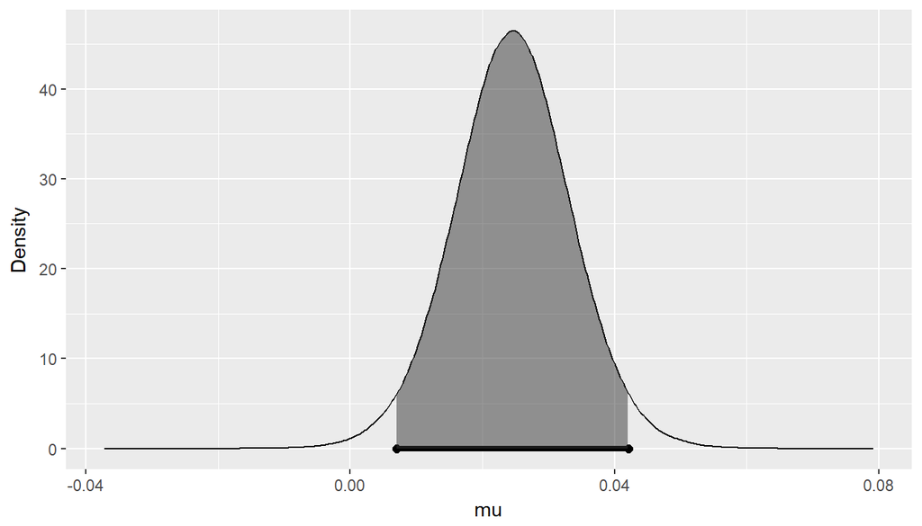

```r
BI=bayes_inference(y = margins, data = df, statistic = "mean", type = "ht", null = 0, alternative = "twosided")
```

```
## Single numerical variable
## n = 24, y-bar = 0.0246, s = 0.0416
## (Assuming improper prior: P(mu, sigma^2) = 1/sigma^2)
##
## Hypotheses:
## H1: mu = 0
## H2: mu != 0
##
## Priors:
## P(H1) = 0.5
## P(H2) = 0.5
##
## Results:
## BF[H2:H1] = 6.0368
## P(H1|data) = 0.1421
## P(H2|data) = 0.8579
```

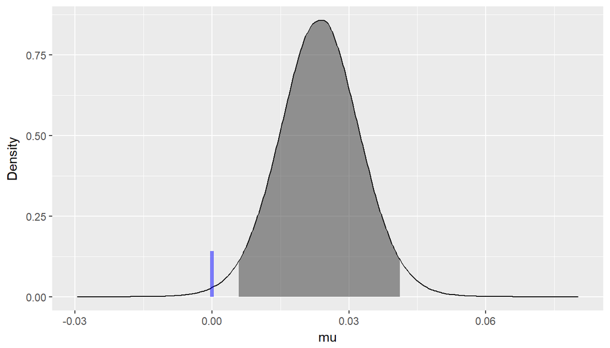

```r
BI
```

```
## $hypothesis_prior
##  H1  H2
## 0.5 0.5
##
## $order
## [1] "H2:H1"
##
## $O
## H2
##  1
##
## $BF
## [1] 6.036847
##
## $PO
##       H2
## 6.036847
##
## $post_H2
##        H2
## 0.8578909
##
## $post_H1
##        H2
## 0.1421091
```

```r
y_bar = mean(df$Margins)
s = sd(df$Margins)
p = pnorm(q=0,mean=y_bar,sd = s,lower.tail = FALSE)
p
```

```
## [1] 0.7227391
```

$$P(\mu > 0) = P(\mu > 0 ~|~ H_1)*P(H_1) + P(\mu > 0 ~|~ H_2)*P(H_2) = P(\mu > 0 ~|~ H_2)*P(H_2)=0.8578909*0.7227391 = 0.6200313$$

Instead of just saying we reject $H_0$, now we can say that there is a 62% probability that the changes have made a significant impact.

If we want to show a one-sided probability (i.e. we assume that if the mean comes from a different distribution, it is greater than 0) we take $P(\mu > 0) = P(\mu > 0|H_0) \times P(H_0)) + P(\mu > 0|H_1) \times P(H_1))/(P(H_0) + P(\mu > 0 | H_1)*P(H_1))$